# PSL: Ridge and Lasso

```python
import pandas as pd
import numpy as np
import matplotlib.pyplot as plt

from sklearn.preprocessing import scale
from sklearn.model_selection import train_test_split
from sklearn.linear_model import LinearRegression as lm
from sklearn.linear_model import Ridge, RidgeCV, Lasso, LassoCV
from sklearn.metrics import mean_squared_error
```

## Load Data

The Prostate data can be found [[here](https://hastie.su.domains/ElemStatLearn/data.html)]. The data is to examine the correlation between the level of prostate-specific antigen and a number of clinical measures in men who were about to receive a radical prostatectomy.

- lcavol: log cancer volume
- lweight: log prostate weight
- age: in years
- lbph: log of the amount of benign prostatic hyperplasia
- svi: seminal vesicle invasion
- lcp: log of capsular penetration
- gleason: a numeric vector
- pgg45: percent of Gleason score 4 or 5
- lpsa: response

The first 8 columns are predictors; column 9 is the outcome/response. We do not use column 10, which indicates which 67 observations were used as the “training set” and which 30 as the test set, as described on page 48 in the ESL book. For convenience, we rename the response column with a generic name Y.

```python
myData = pd.read_csv("https://hastie.su.domains/ElemStatLearn/datasets/prostate.data", sep='\t')
myData = myData.drop(columns=[myData.columns[0], myData.columns[10]])
myData.head()
```

|  | lcavol | lweight | age | lbph | svi | lcp | gleason | pgg45 | lpsa |
| --- | --- | --- | --- | --- | --- | --- | --- | --- | --- |
| 0 | -0.579818 | 2.769459 | 50 | -1.386294 | 0 | -1.386294 | 6 | 0 | -0.430783 |
| 1 | -0.994252 | 3.319626 | 58 | -1.386294 | 0 | -1.386294 | 6 | 0 | -0.162519 |
| 2 | -0.510826 | 2.691243 | 74 | -1.386294 | 0 | -1.386294 | 7 | 20 | -0.162519 |
| 3 | -1.203973 | 3.282789 | 58 | -1.386294 | 0 | -1.386294 | 6 | 0 | -0.162519 |
| 4 | 0.751416 | 3.432373 | 62 | -1.386294 | 0 | -1.386294 | 6 | 0 | 0.371564 |

```python
myData.shape
```

```
(97, 9)
```

```python
X = myData.iloc[:, :-1]
Y = myData.iloc[:, -1]
X.shape, len(Y)
```

```
((97, 8), 97)
```

## Train/Test Split

Split the data into two parts: 80% for training and 20% for testing. Throughout, we will use the the training data to select variables and estimate coefficients and report the average MSE on the test data.

```python
X_train, X_test , Y_train, Y_test = train_test_split(X, Y, test_size=0.2, random_state=1)
```

## Full Model

Fit an ordinary linear regression model using all variables.

```python
full_model = lm()
full_model.fit(X_train, Y_train)
# averaged MSE on the test set
mean_squared_error(Y_test, full_model.predict(X_test))
```

```
0.40319945539779695
```

## Ridge Regression

Plot the ridge coefficients against the range of **alpha** values in Python. It's important to note that the **alpha** parameter in Python's Ridge regression is equivalent to **lambda** in R's Ridge regression. The term alpha in R denotes something different.

```python
alphas = np.logspace(-3, 3, 100)
ridge = Ridge(normalize = True)
coefs = []

for a in alphas:
    ridge.set_params(alpha = a)
    ridge.fit(X_train, Y_train)
    coefs.append(ridge.coef_)

np.shape(coefs)
```

```
(100, 8)
```

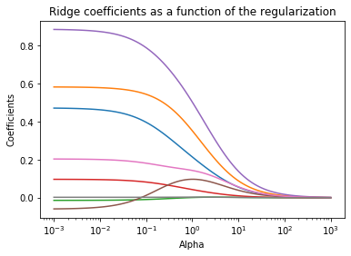

```python
ax = plt.gca()

ax.plot(alphas, coefs)
ax.set_xscale('log')
plt.xlabel('Alpha')
plt.ylabel('Coefficients')
plt.title('Ridge coefficients as a function of the regularization')
plt.axis('tight')
plt.show()
```

### Tune alpha by 10-fold CV with MSE

```python
ridgecv = RidgeCV(alphas = alphas, cv = 10,
                  scoring = 'neg_mean_squared_error',
                  normalize = True)
ridgecv.fit(X_train, Y_train)
ridgecv.alpha_
```

```
0.26560877829466867
```

### Evaluate prediction performance

```python
ridge_model = Ridge(alpha = ridgecv.alpha_, normalize = True)
ridge_model.fit(X_train, Y_train)
mean_squared_error(Y_test, ridge_model.predict(X_test))
```

```
0.5057873761573645
```

Note that none of the ridge regressions is exactly zero.

```python
pd.Series(ridge_model.coef_, index = X.columns)
```

```
lcavol     0.328243
lweight    0.491542
age       -0.005151
lbph       0.068130
svi        0.695180
lcp        0.061868
gleason    0.164950
pgg45      0.002653
dtype: float64
```

### CV Path Plot

Generate a cross-validation path plot similar to the one from R's glmnet. In order to generate this plot, we need to manually implement cross-validation for Ridge regression.

```python
from sklearn.model_selection import cross_val_score
```

```python
mean_mse = []
std_mse = []

# Loop through each alpha and perform cross-validation
for alpha in alphas:
    ridge = Ridge(alpha=alpha, normalize = True)
    mse_scores = -cross_val_score(ridge, X_train, Y_train, cv=10, scoring='neg_mean_squared_error')  # 10-fold CV
    mean_mse.append(np.mean(mse_scores))
    std_mse.append(np.std(mse_scores) / np.sqrt(10))
```

```python
# Identify best alpha and one standard error rule alpha
min_idx = np.argmin(mean_mse)
alpha_min = alphas[min_idx]

# Find the threshold within one standard error of the best alpha
threshold = mean_mse[min_idx] + std_mse[min_idx]

# Find the largest alpha within one standard error of the best alpha
one_se_rule_idx = np.where(mean_mse <= threshold)[0][-1]
alpha_1se = alphas[one_se_rule_idx]

alpha_min, alpha_1se
```

```
(0.26560877829466867, 1.629750834620645)
```

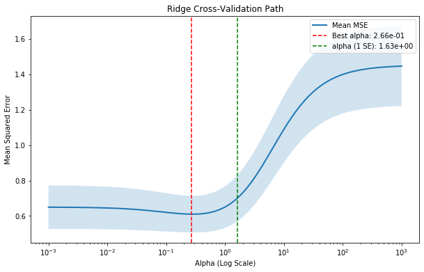

```python
mean_mse = np.array(mean_mse)
std_mse = np.array(std_mse)

plt.figure(figsize=(10, 6))
plt.semilogx(alphas, mean_mse, label='Mean MSE', linewidth=2)
plt.fill_between(alphas, mean_mse - std_mse, mean_mse + std_mse, alpha=0.2)
plt.axvline(alpha_min, linestyle='--', color='r', label=f'Best alpha: {alpha_min:.2e}')
plt.axvline(alpha_1se, linestyle='--', color='g', label=f'alpha (1 SE): {alpha_1se:.2e}')
plt.xlabel('Alpha (Log Scale)')
plt.ylabel('Mean Squared Error')
plt.legend()
plt.title('Ridge Cross-Validation Path')
plt.show()
```

## Lasso Regression

```python
alphas = np.logspace(-4, -1, 100)
lasso = Lasso(normalize = True)
coefs = []

for a in alphas:
    lasso.set_params(alpha = a)
    lasso.fit(X_train, Y_train)
    coefs.append(lasso.coef_)

np.shape(coefs)
```

```
(100, 8)
```

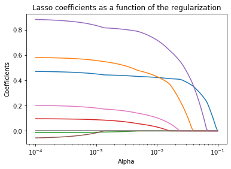

```python
ax = plt.gca()

ax.plot(alphas, coefs)
ax.set_xscale('log')
plt.xlabel('Alpha')
plt.ylabel('Coefficients')
plt.title('Lasso coefficients as a function of the regularization')
plt.axis('tight')
plt.show()
```

### Tune alpha by 10-fold CV with MSE

```python
lassocv = LassoCV(alphas = alphas, cv = 10,
                  normalize = True)
lassocv.fit(X_train, Y_train)
lassocv.alpha_
```

```
0.00572236765935022
```

### Evaluate prediction performance

```python
lasso_model = Lasso(alpha = lassocv.alpha_, normalize = True)
lasso_model.fit(X_train, Y_train)
mean_squared_error(Y_test, lasso_model.predict(X_test))
```

```
0.43426555165941305
```

Note that some lasso regressions are exactly zero.

```python
pd.Series(lasso_model.coef_, index = X.columns)
```

```
lcavol     0.428929
lweight    0.469259
age       -0.000000
lbph       0.052529
svi        0.775122
lcp        0.000000
gleason    0.133524
pgg45      0.001010
dtype: float64
```

Variables that are not selected.

```python
X.columns[np.where(lasso_model.coef_ == 0)]
```

```
Index(['age', 'lcp'], dtype='object')
```

In some runs, the optimal alpha value is at the boundary, for example, `alphas[0]`. Then we should expand the range of alphas and re-run `LassoCV`.

### CV Path Plot

Generate a cross-validation path plot similar to the one from R's glmnet.

```python
lassocv = LassoCV(alphas=alphas, cv=10, normalize = True)
lassocv.fit(X_train, Y_train)

lassocv.alpha_
```

```
0.00572236765935022
```

```python
# Extract mean and standard
mean_mse = np.mean(lassocv.mse_path_, axis=1)
std_mse = np.std(lassocv.mse_path_, axis=1) / np.sqrt(10)
```

```python
# Extract alphas from CV output
# Note: they may not be in the same order as the alpha sequence your provide to lassoCV
cv_alphas = lassocv.alphas_
# Identify best alpha and one standard error rule alpha
min_idx = np.argmin(mean_mse)
alpha_min = cv_alphas[min_idx]

# Find the threshold within one standard error of the best alpha
threshold = mean_mse[min_idx] + std_mse[min_idx]

# Find the largest alpha within one standard error of the best alpha
alpha_1se = max(cv_alphas[np.where(mean_mse <= threshold)])

alpha_min, alpha_1se  #alpha_min = lassocv.alpha_
```

```
(0.00572236765935022, 0.02848035868435802)
```

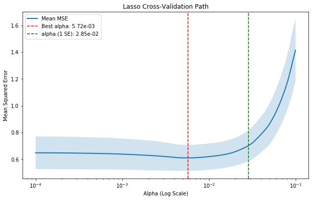

```python
mean_mse = np.array(mean_mse)
std_mse = np.array(std_mse)

plt.figure(figsize=(10, 6))
plt.semilogx(cv_alphas, mean_mse, label='Mean MSE', linewidth=2)
plt.fill_between(cv_alphas, mean_mse - std_mse, mean_mse + std_mse, alpha=0.2)
plt.axvline(alpha_min, linestyle='--', color='r', label=f'Best alpha: {alpha_min:.2e}')
plt.axvline(alpha_1se, linestyle='--', color='g', label=f'alpha (1 SE): {alpha_1se:.2e}')
plt.xlabel('Alpha (Log Scale)')
plt.ylabel('Mean Squared Error')
plt.legend()
plt.title('Lasso Cross-Validation Path')
plt.show()
```

### Evaluate prediction performance with alpha_1se

```python
lasso_1se_model = Lasso(alpha = alpha_1se, normalize = True)
lasso_1se_model.fit(X_train, Y_train)
mean_squared_error(Y_test, lasso_1se_model.predict(X_test))
```

```
0.44811214582804604
```

### Refit to Reduce Bias

We refit an ordinary linear regression model using the variables selected by `alpha_1se` and then use it for prediction.

```python
lasso_1se_model.coef_
```

```
array([0.39323023, 0.1665207 , 0.        , 0.        , 0.49792202,
       0.        , 0.        , 0.        ])
```

```python
nonzero_indices = np.where(lasso_1se_model.coef_ != 0)[0]
lm_refit = lm()
lm_refit.fit(X_train.iloc[:, nonzero_indices], Y_train)
mean_squared_error(Y_test, lm_refit.predict(X_test.iloc[:, nonzero_indices]))
```

```
0.3811396432678013
```